# Lab 8

Samuel Kelly

2021-03-29

# Task 1

```r
getwd()
```

```
## [1] "C:/Users/semyu/OneDrive/Desktop/IDE/RPackages/MATH4753Kelly/MATH4753-Applied Statistical Methods/LABS/Lab 8"
```

# Task 2

## Make our own sample using runif, which creates a uniform distribution

```r
sample.size = 10
lower = 0
upper = 5
sample = runif(sample.size,lower,upper)
sample
```

```
##  [1] 1.3499889 3.0467218 0.8772068 0.3876757 1.6970161 2.0518124 1.1341803
##  [8] 1.7776434 0.1815320 4.2414523
```

## Mean

```r
mu = (lower+upper)/2
```

## Variance

```r
v = ((upper-lower)^2)/12
```

## Mean and Varince

```r
noquote(paste0("The mean is: ", mu, ", and the variance is: ", round(v,4), "."))
```

```
## [1] The mean is: 2.5, and the variance is: 2.0833.
```

## Sample mean and variance

```r
xbar = mean(sample)
ssq = var(sample)
noquote(paste0("The mean is: ", round(xbar,4), ", and the variance is: ", round(ssq,4), "."))
```

```
## [1] The mean is: 1.6745, and the variance is: 1.5048.
```

$$\text{The sum of T is the sum of all }Y_{i} \text{: E(T)=} E(nY_{i})=n\frac{a+b}{2},\text{ where a is lower, and b is upper.}$$
$$\text{The mean of } \bar{Y}:E(\bar{Y})=E(Y_{i})=\mu=\frac{a+b}{2}$$
$$\text{The variance of sum T is: }V(T)=V(Y_{i})=n\sigma^2=n\frac{(b-a)^2}{12}.$$
$$\text{The variance of }\bar{Y}:V(\bar{Y})=\frac{1}{n}*\sigma^2=\frac{(b-a)^2}{12n}.$$

## CLT

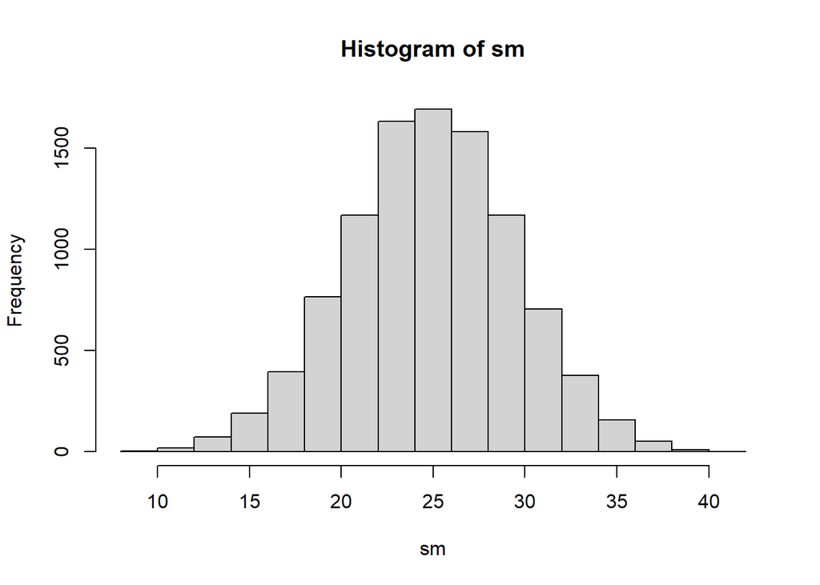

```r
myclt=function(n,iter){
y=runif(n*iter,0,5) # A: Creates a uniform distribution of size n*iter that is stored in y.
data=matrix(y,nr=n,nc=iter,byrow=TRUE) #B: Stores the values of the uniform distribution in a matrix with n rows and iter columns, where each column represents a sample of size n, and this is stored in the variable data.
sm=apply(data,2,sum) #C: We apply the sum function on our data set data, and we specify 1 if we want rows, and 2 for columns, so we are summing each column and storing it into sm.
hist(sm)
sm
}
w=myclt(n=10,iter=10000) #D: We call the myclt function with parameters that will output a histogram of our sums of columns, and stores the results in w.
```

## Mean of w

```r
mean(w)
```

```
## [1] 24.87678
```

## Variance

```r
var(w)
```

```
## [1] 20.80144
```

## Sample means

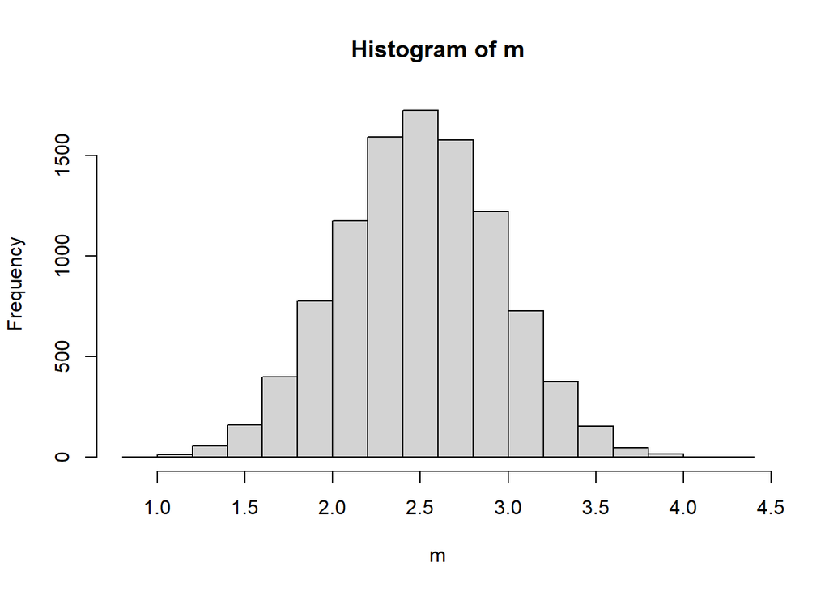

```r
myclt.mean=function(n,iter){
y=runif(n*iter,0,5) # A: Creates a uniform distribution of size n*iter that is stored in y.
data=matrix(y,nr=n,nc=iter,byrow=TRUE) #B: Stores the values of the uniform distribution in a matrix with n rows and iter columns, where each column represents a sample of size n, and this is stored in the variable data.
m=apply(data,2,mean) #C: We apply the mean function on our data set data, and we specify 1 if we want rows, and 2 for columns, so we mean each column and storing it into m.
hist(m)
m
}
w=myclt.mean(n=10,iter=10000) #D: We call the myclt function with parameters that will output a histogram of our means of columns, and stores the results in w.
```

## Mean of w

```r
mean(w)
```

```
## [1] 2.496554
```

## Variance of w

```r
var(w)
```

```
## [1] 0.2037492
```

## Task 3

## CLTU

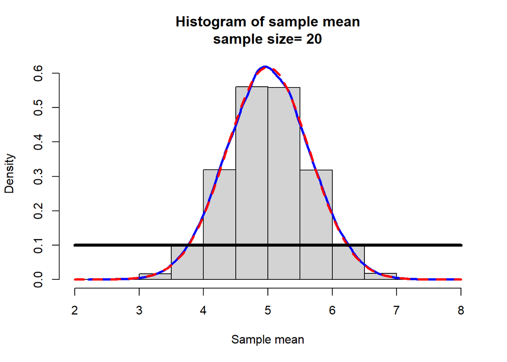

```r
mycltu=function(n,iter,a=0,b=10){
## r-random sample from the uniform
y=runif(n*iter,a,b)
## Place these numbers into a matrix
## The columns will correspond to the iteration and the rows will equal the sample size n
data=matrix(y,nr=n,nc=iter,byrow=TRUE)
## apply the function mean to the columns (2) of the matrix
## these are placed in a vector w
w=apply(data,2,mean) #### the 2 refers that we are applying the function to the columns
## We will make a histogram of the values in w
## How high should we make y axis?
## All the values used to make a histogram are placed in param (nothing is plotted yet)
param=hist(w,plot=FALSE)
## Since the histogram will be a density plot we will find the max density

ymax=max(param$density)
## To be on the safe side we will add 10% more to this
ymax=1.1*ymax
## Now we can make the histogram
hist(w,freq=FALSE,  ylim=c(0,ymax), main=paste("Histogram of sample mean",
"\n", "sample size= ",n,sep=""),xlab="Sample mean")
## add a density curve made from the sample distribution
lines(density(w),col="Blue",lwd=3) # add a density plot
## Add a theoretical normal curve
curve(dnorm(x,mean=(a+b)/2,sd=(b-a)/(sqrt(12*n))),add=TRUE,col="Red",lty=2,lwd=3) # add a theoretical curve
## Add the density from which the samples were taken
curve(dunif(x,a,b),add=TRUE,lwd=4)

}
w = mycltu(n = 20,iter = 100000)
```

The 2 refers that we are applying the function “mean” to the columns of the data set. Since runif take a sample size of n * iter then 20 * 100000 = 2,000,000 terms. The standard deviation is different from the variance, specifically the standard devication is the square root of the variance.
$$\sigma^2=\frac{(b-a)^2}{12},\sigma=\frac{b-a}{\sqrt{12}},~or~V(\bar{Y})=\frac{1}{n}V(Y),~so~\sigma=\frac{b-a}{\sqrt{12n}}$$

## Iterations

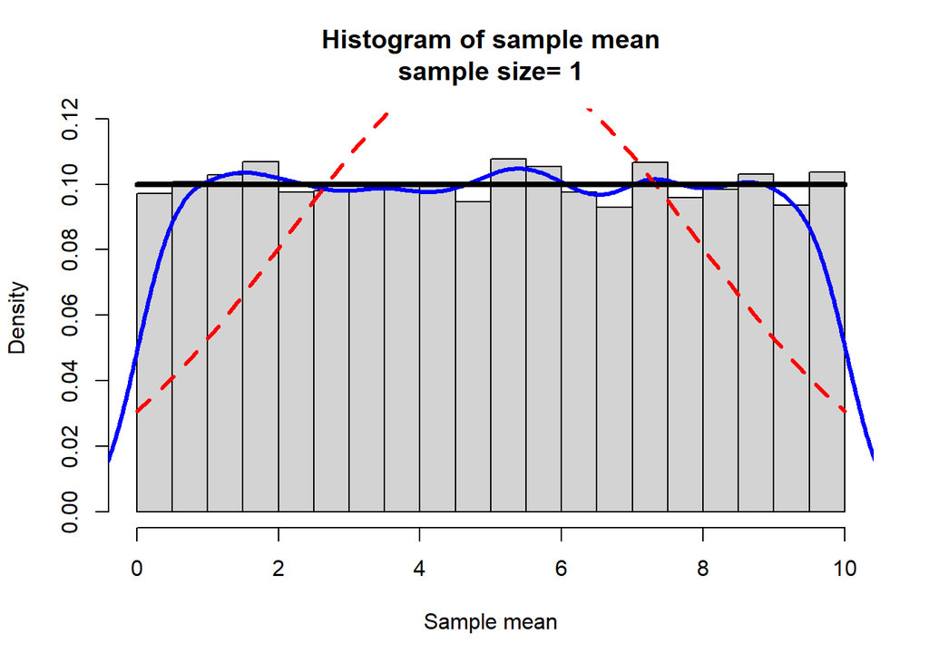

```r
mycltu(n = 1,iter = 10000,a = 0,b = 10)
```

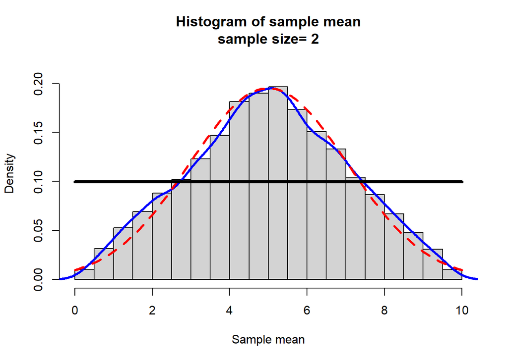

```r
mycltu(n = 2,iter = 10000,a = 0,b = 10)
```

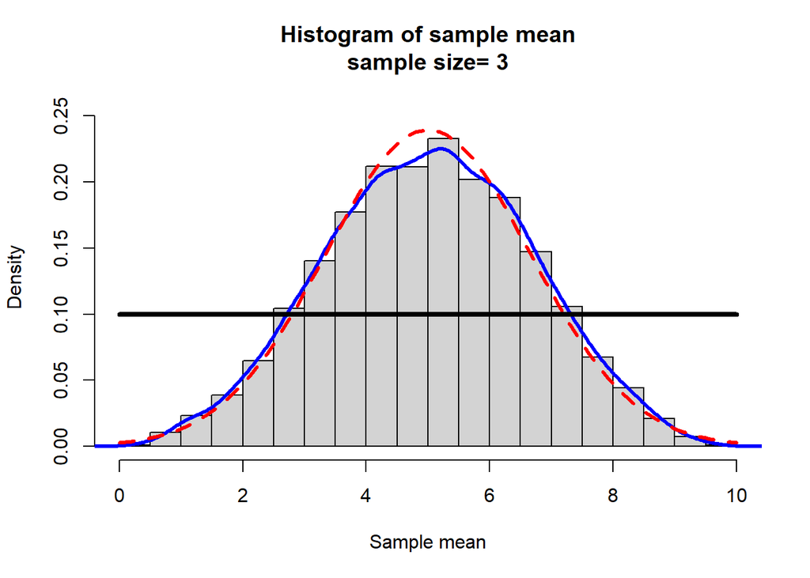

```r
mycltu(n = 3,iter = 10000,a = 0,b = 10)
```

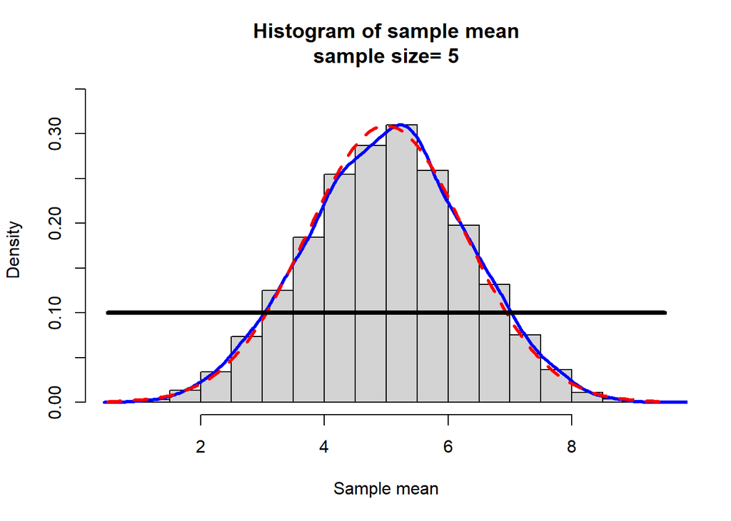

```r
mycltu(n = 5,iter = 10000,a = 0,b = 10)
```

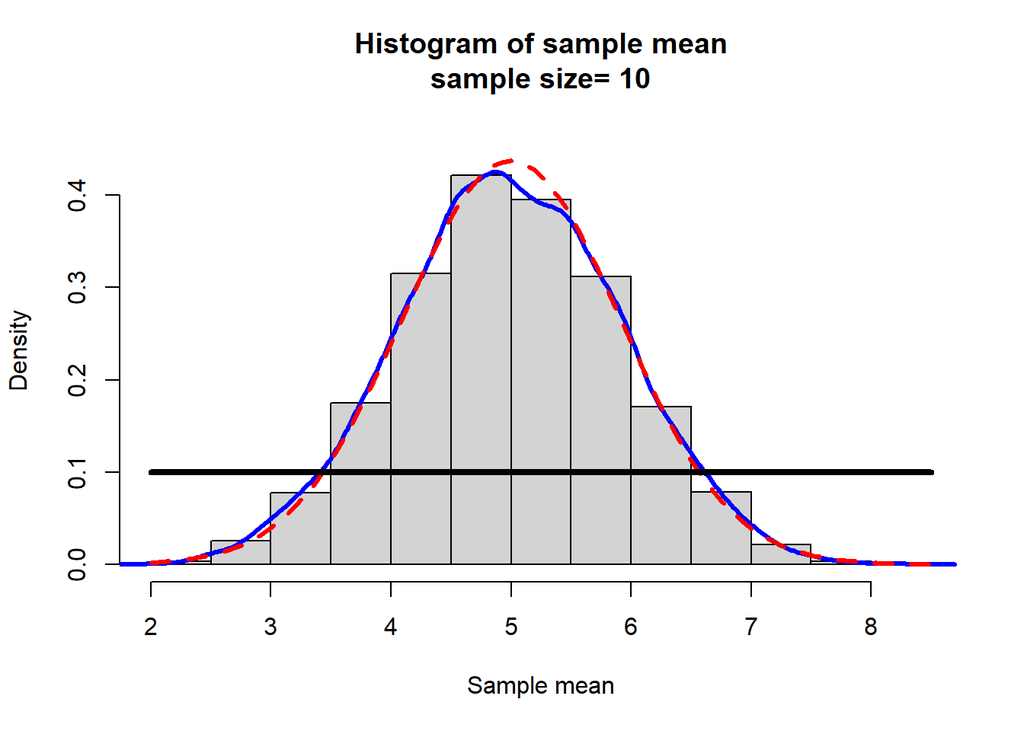

```r
mycltu(n = 10,iter = 10000,a = 0,b = 10)
```

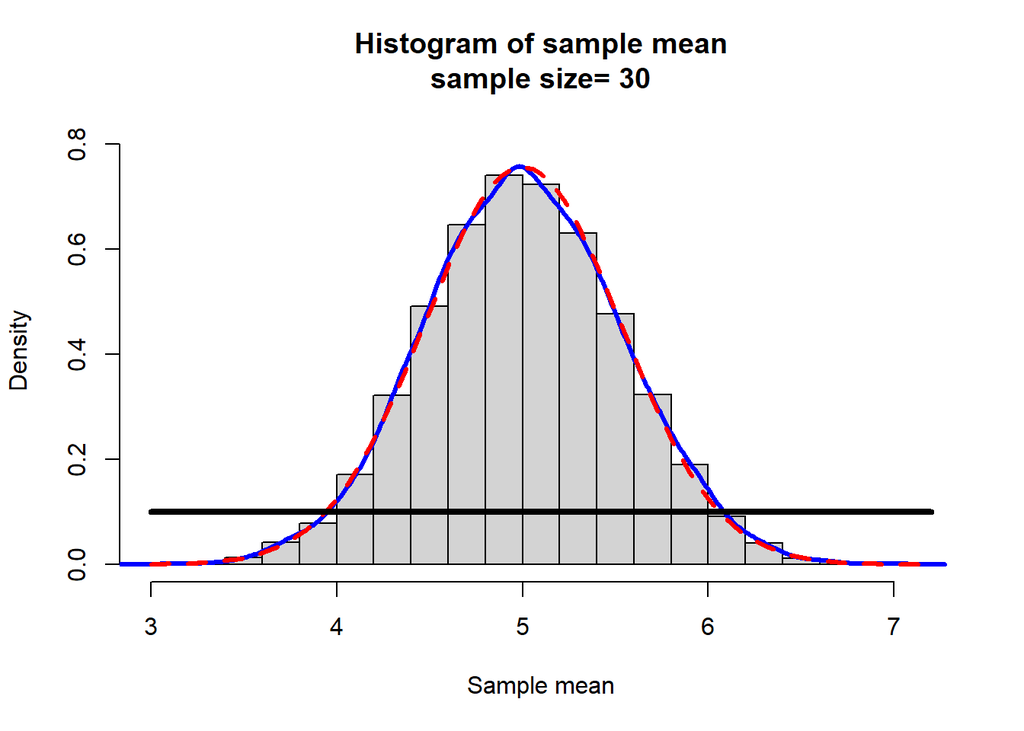

```r
mycltu(n = 30,iter = 10000,a = 0,b = 10)
```

The dunif curve that’s a straight line is the mean from 0 to 10, and it does not change from changes in sample size as it remains at .1 through all the histograms. We can see the distribution change it’s shape from uniform to looking like a normal distribution when the sample size increases.

# Task 4

## mycltb

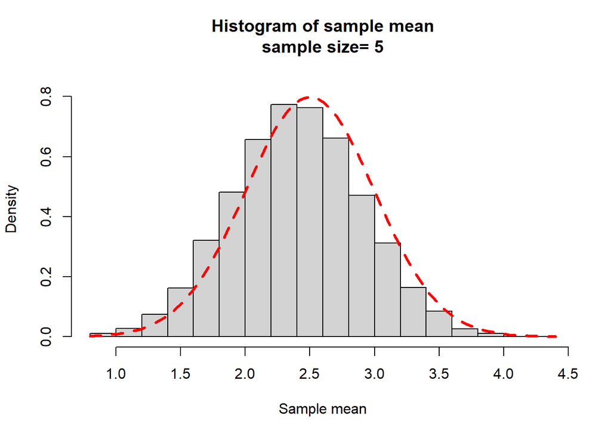

```r
mycltb=function(n,iter,p=0.5,...){

## r-random sample from the Binomial
y=rbinom(n*iter,size=n,prob=p)
## Place these numbers into a matrix
## The columns will correspond to the iteration and the rows will equal the sample size n
data=matrix(y,nr=n,nc=iter,byrow=TRUE)
## apply the function mean to the columns (2) of the matrix
## these are placed in a vector w
w=apply(data,2,mean)
## We will make a histogram of the values in w
## How high should we make y axis?
## All the values used to make a histogram are placed in param (nothing is plotted yet)
param=hist(w,plot=FALSE)
## Since the histogram will be a density plot we will find the max density

ymax=max(param$density)
## To be on the safe side we will add 10% more to this
ymax=1.1*ymax

## Now we can make the histogram
## freq=FALSE means take a density
hist(w,freq=FALSE,  ylim=c(0,ymax),
main=paste("Histogram of sample mean","\n", "sample size= ",n,sep=""),
xlab="Sample mean",...)
## add a density curve made from the sample distribution
#lines(density(w),col="Blue",lwd=3) # add a density plot
## Add a theoretical normal curve
curve(dnorm(x,mean=n*p,sd=sqrt(p*(1-p))),add=TRUE,col="Red",lty=2,lwd=3)

}
mycltb(n=5,iter=10000,p=0.5)
```

## Iterations of p = .3

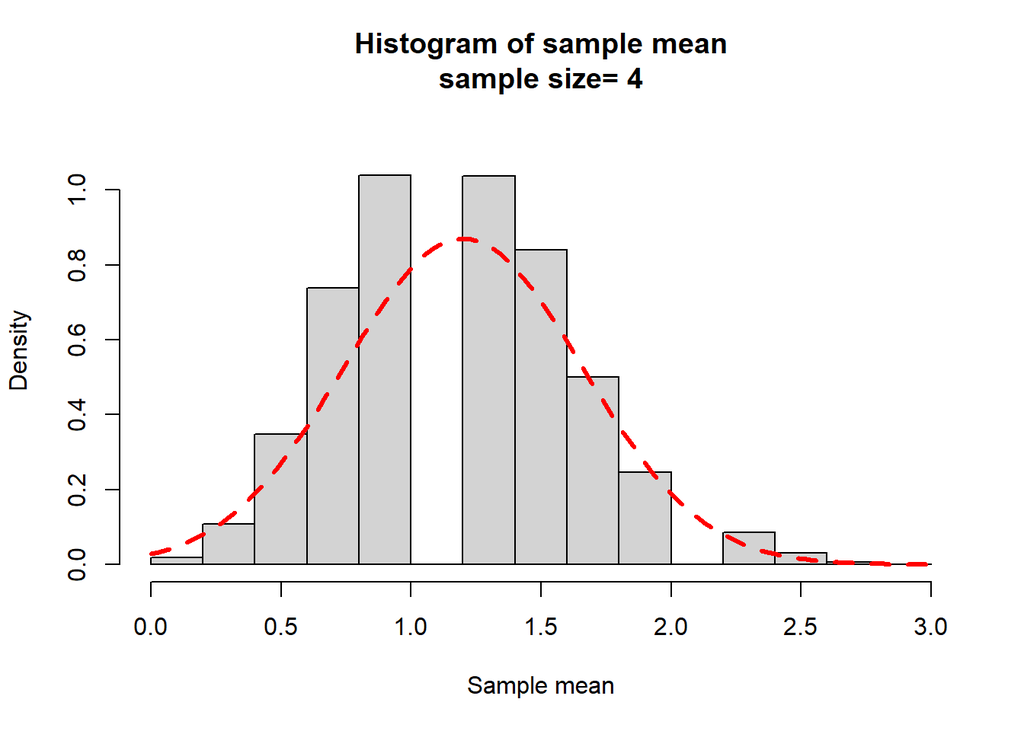

```r
mycltb(n = 4,iter = 10000,p = .3)
```

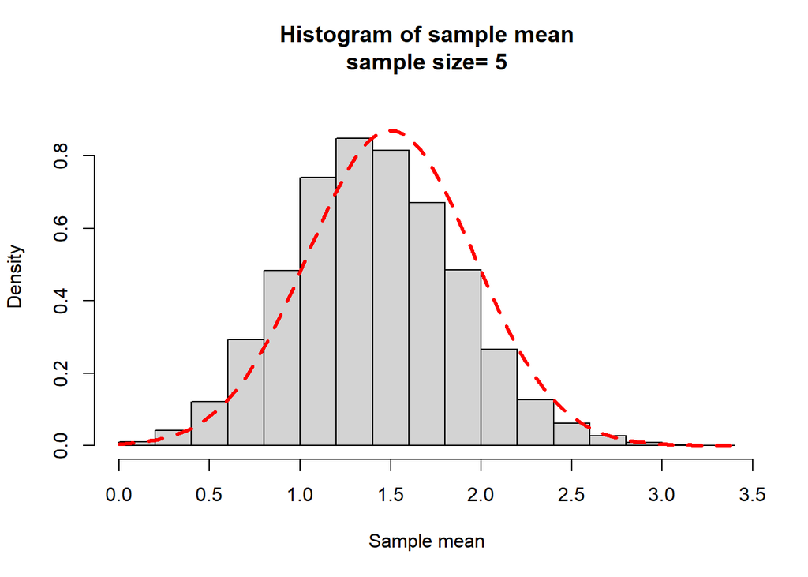

```r
mycltb(n = 5,iter = 10000,p = .3)
```

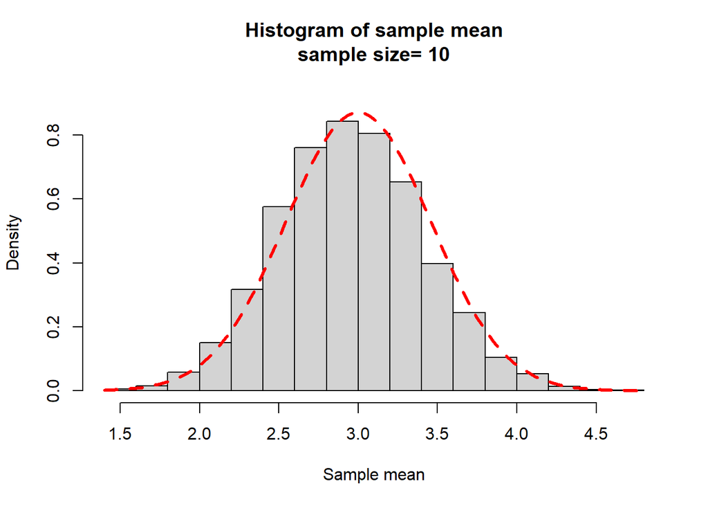

```r
mycltb(n = 10,iter = 10000,p = .3)
```

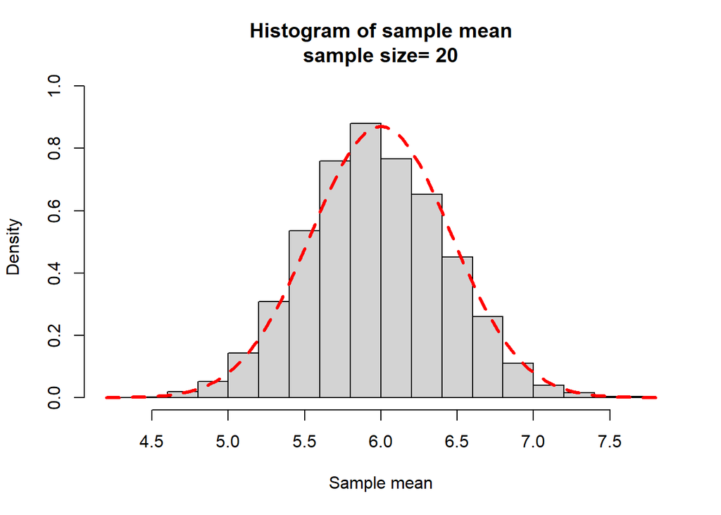

```r
mycltb(n = 20,iter = 10000,p = .3)
```

## Iterations of p = .7

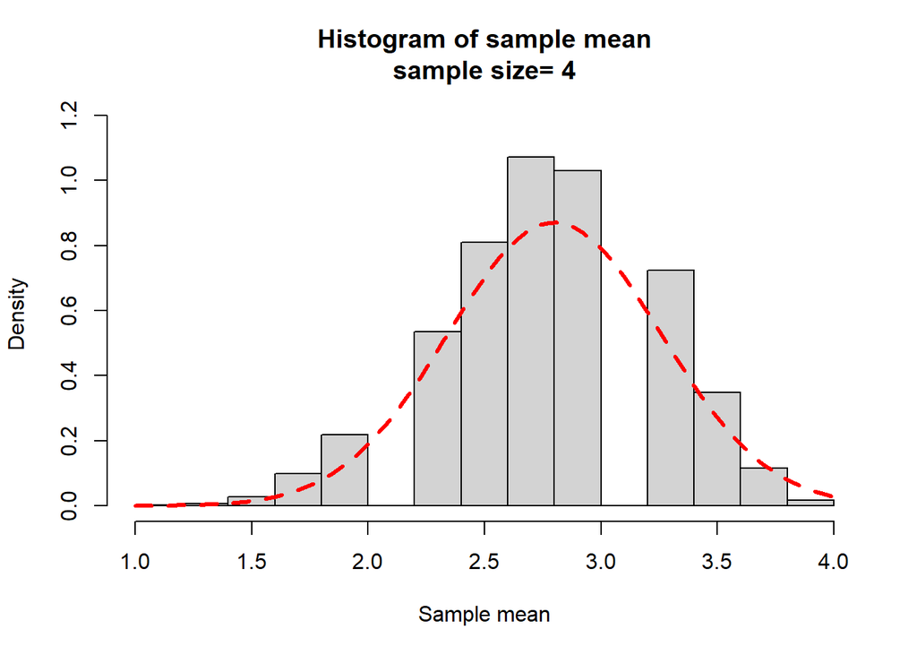

```r
mycltb(n = 4,iter = 10000,p = .7)
```

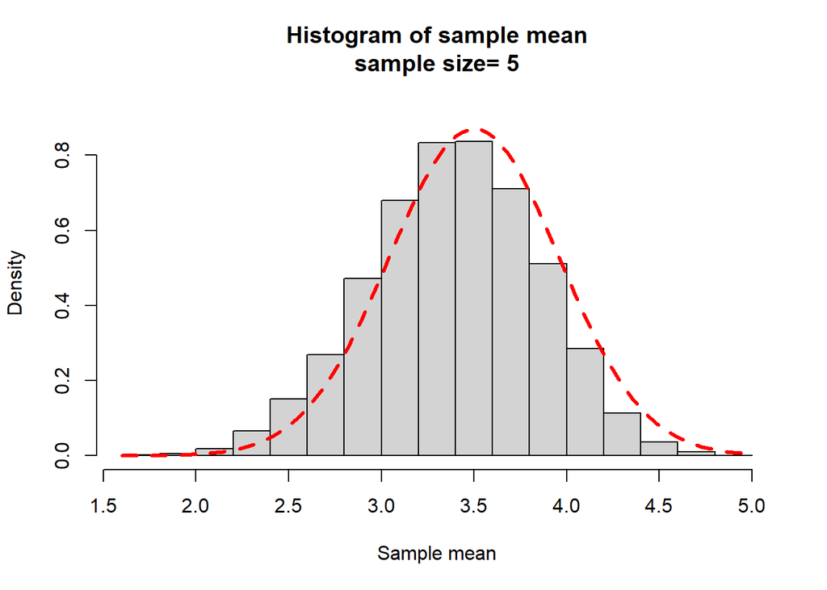

```r
mycltb(n = 5,iter = 10000,p = .7)
```

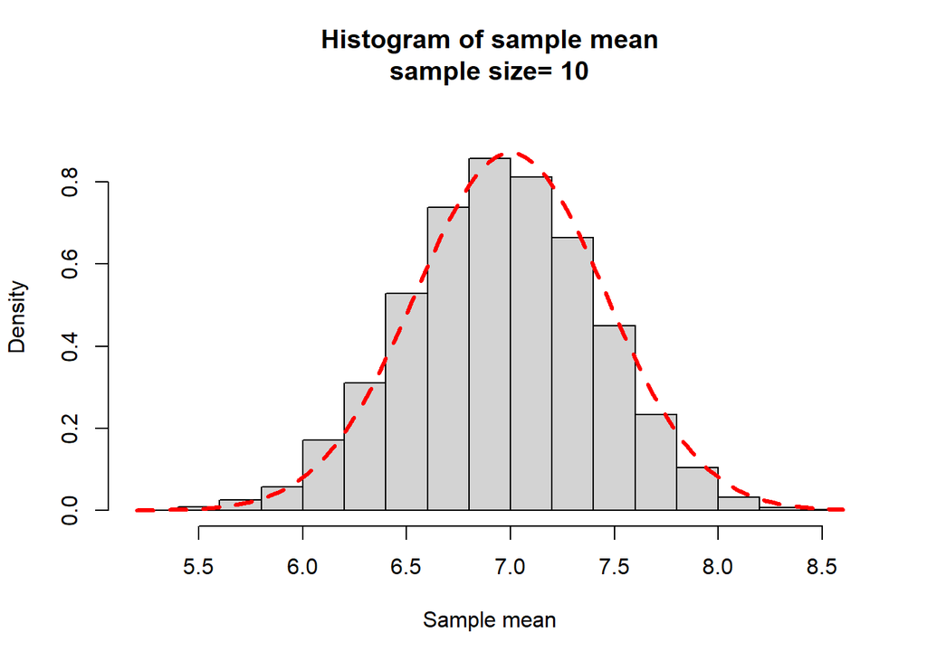

```r
mycltb(n = 10,iter = 10000,p = .7)
```

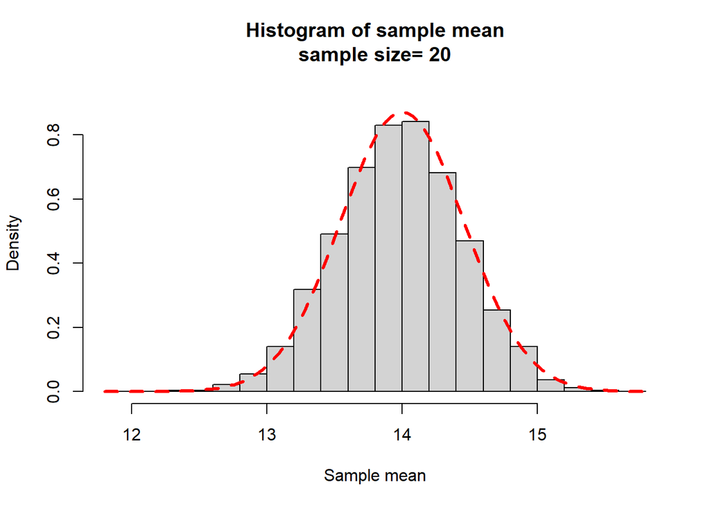

```r
mycltb(n = 20,iter = 10000,p = .7)
```

## Iterations of p = .5

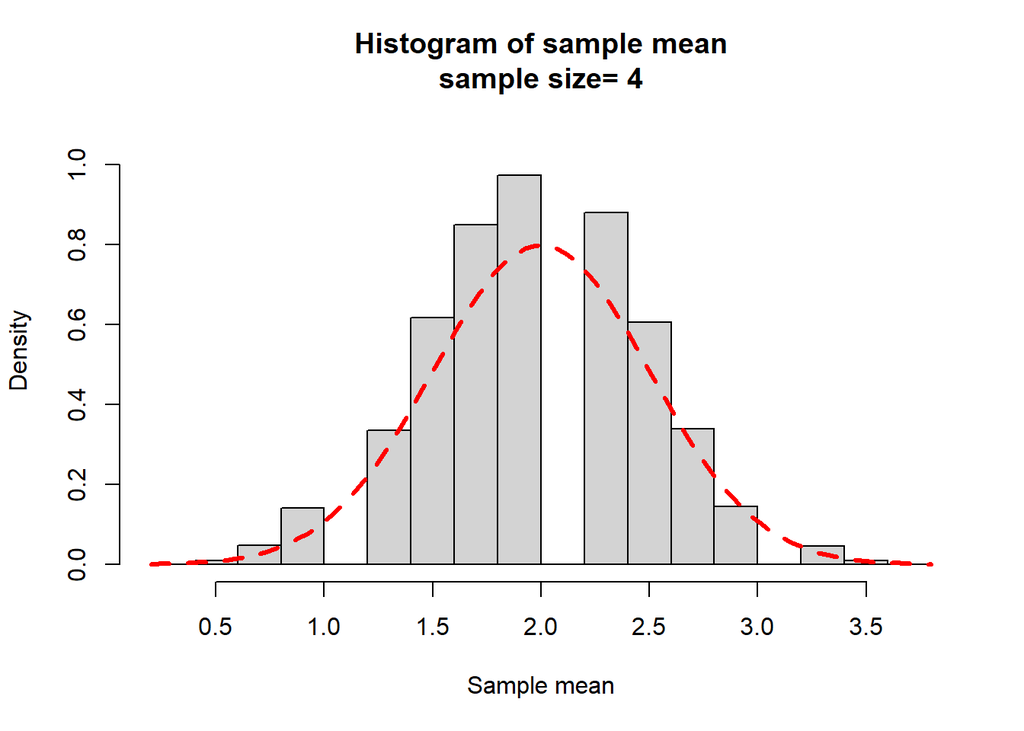

```r
mycltb(n = 4,iter = 10000,p = .5)
```

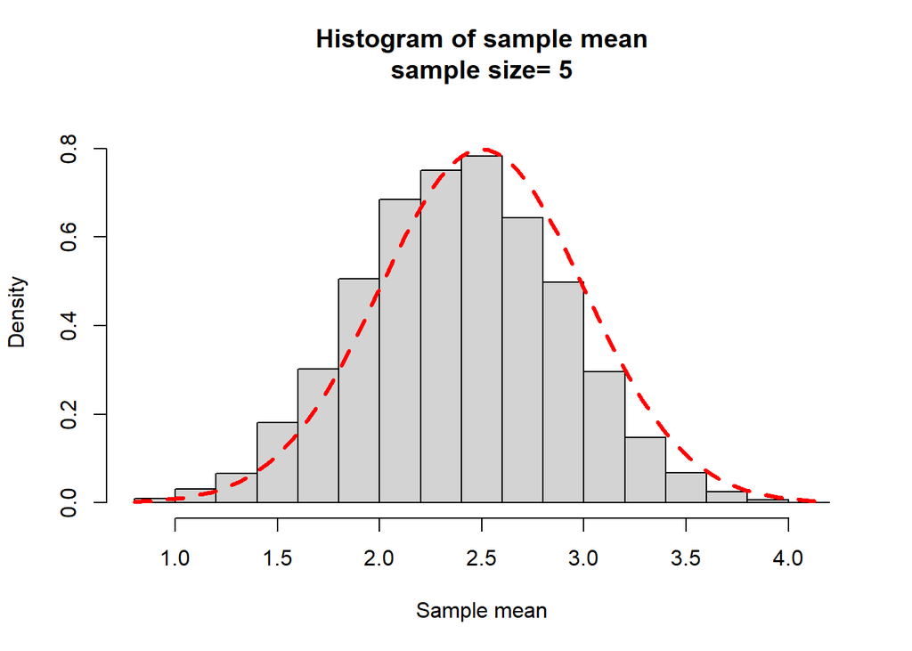

```r
mycltb(n = 5,iter = 10000,p = .5)
```

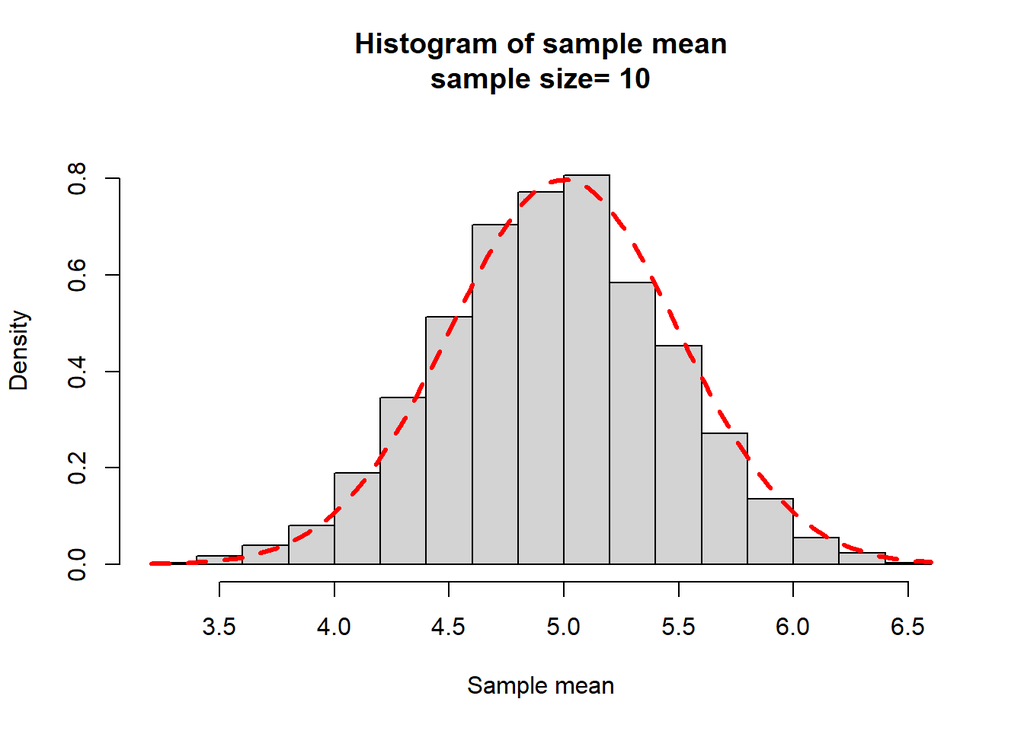

```r
mycltb(n = 10,iter = 10000,p = .5)
```

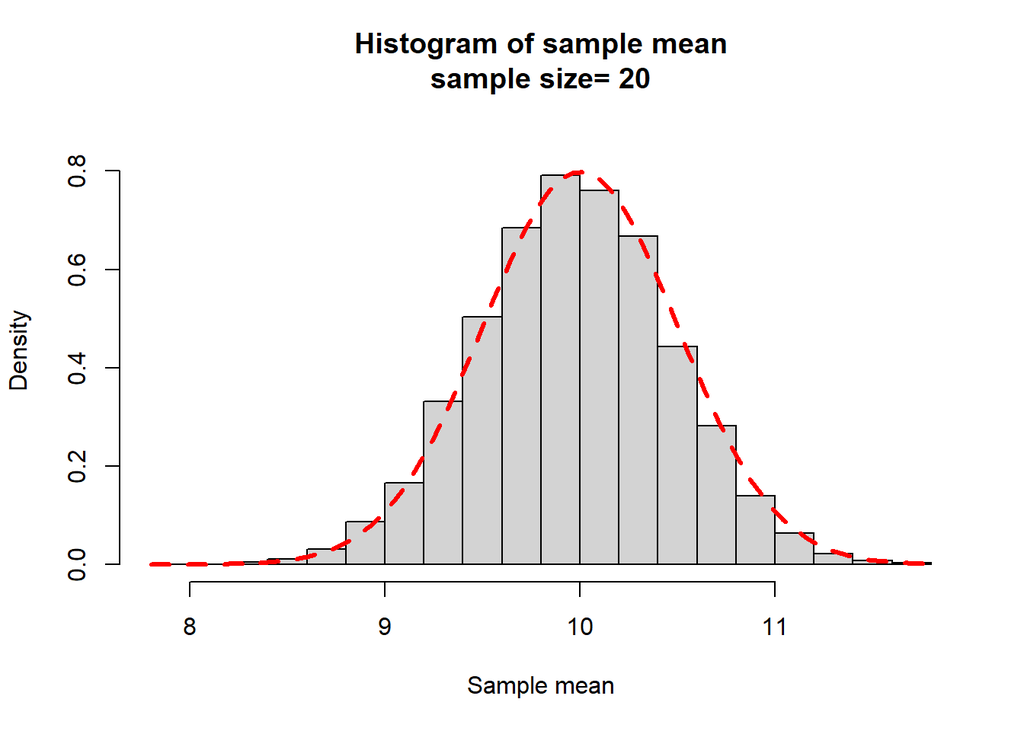

```r
mycltb(n = 20,iter = 10000,p = .5)
```

# Task 5

## mycltp

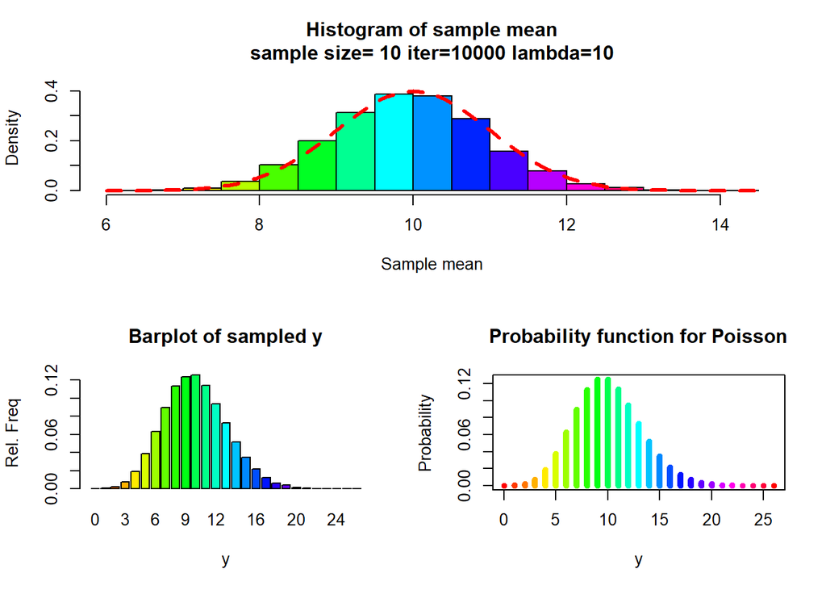

```r
mycltp=function(n,iter,lambda=10,...){

## r-random sample from the Poisson
y=rpois(n*iter,lambda=lambda)
## Place these numbers into a matrix
## The columns will correspond to the iteration and the rows will equal the sample size n
data=matrix(y,nr=n,nc=iter,byrow=TRUE)
## apply the function mean to the columns (2) of the matrix
## these are placed in a vector w
w=apply(data,2,mean)
## We will make a histogram of the values in w
## How high should we make y axis?
## All the values used to make a histogram are placed in param (nothing is plotted yet)
param=hist(w,plot=FALSE)
## Since the histogram will be a density plot we will find the max density

ymax=max(param$density)
## To be on the safe side we will add 10% more to this
ymax=1.1*ymax

## Make a suitable layout for graphing
layout(matrix(c(1,1,2,3),nr=2,nc=2, byrow=TRUE))

## Now we can make the histogram
hist(w,freq=FALSE,  ylim=c(0,ymax), col=rainbow(max(w)),
main=paste("Histogram of sample mean","\n", "sample size= ",n," iter=",iter," lambda=",lambda,sep=""),
xlab="Sample mean",...)
## add a density curve made from the sample distribution
#lines(density(w),col="Blue",lwd=3) # add a density plot
## Add a theoretical normal curve
curve(dnorm(x,mean=lambda,sd=sqrt(lambda/n)),add=TRUE,col="Red",lty=2,lwd=3) # add a theoretical curve

# Now make a new plot
# Since y is discrete we should use a barplot
barplot(table(y)/(n*iter),col=rainbow(max(y)), main="Barplot of sampled y", ylab ="Rel. Freq",xlab="y" )
x=0:max(y)
plot(x,dpois(x,lambda=lambda),type="h",lwd=5,col=rainbow(max(y)),
main="Probability function for Poisson", ylab="Probability",xlab="y")
}
mycltp(n=10,iter=10000)
```

## Iterations lambda=4

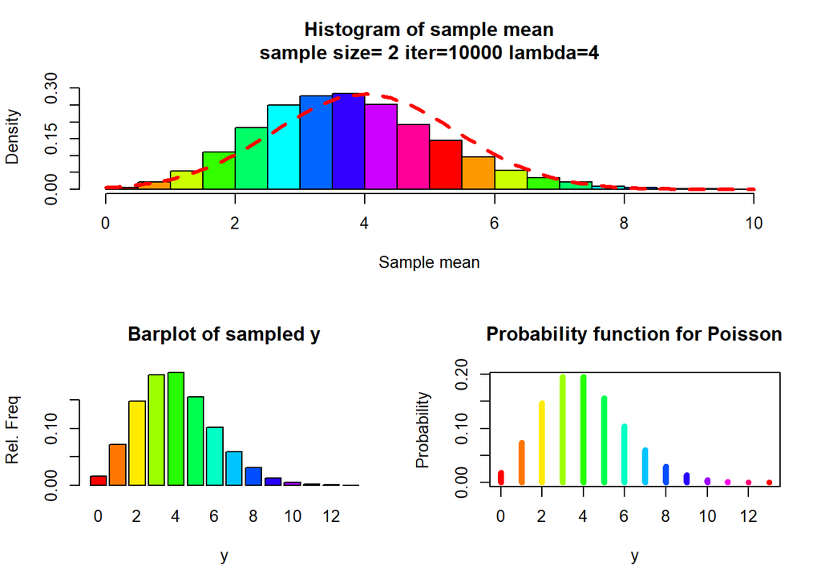

```r
mycltp(n = 2,iter = 10000,lambda = 4)
```

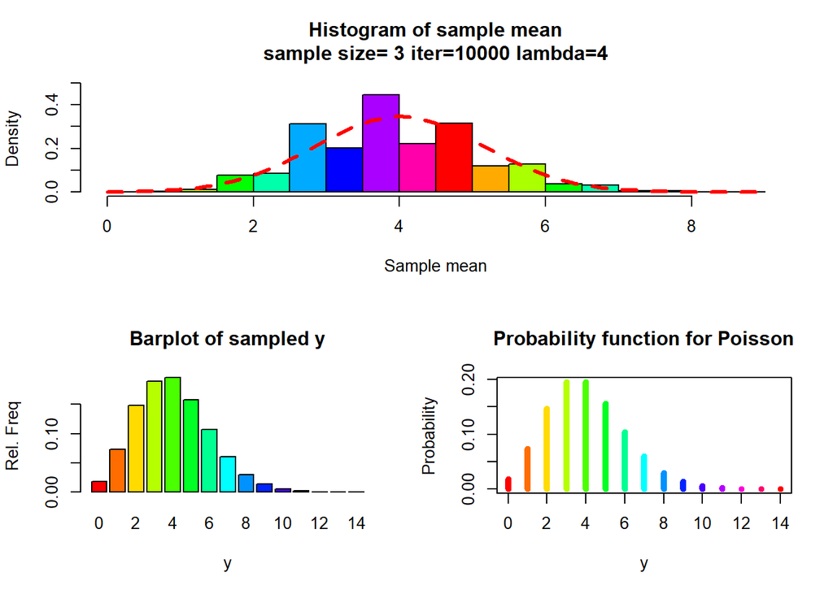

```r
mycltp(n = 3,iter = 10000,lambda = 4)
```

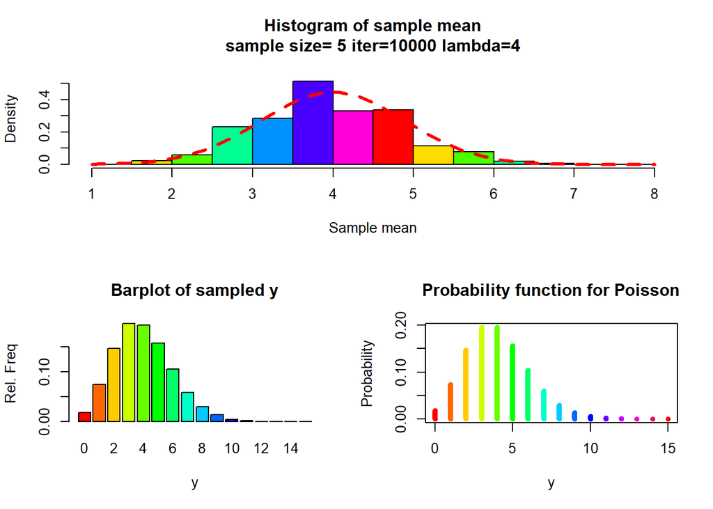

```r
mycltp(n = 5,iter = 10000,lambda = 4)
```

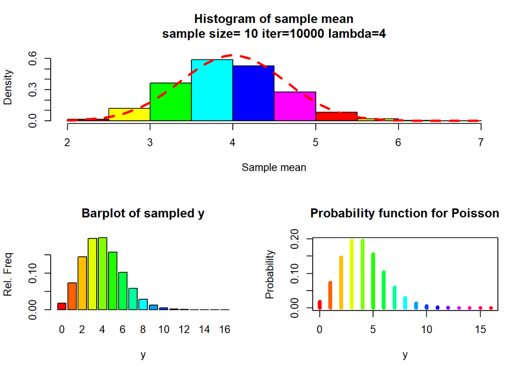

```r
mycltp(n = 10,iter = 10000,lambda = 4)
```

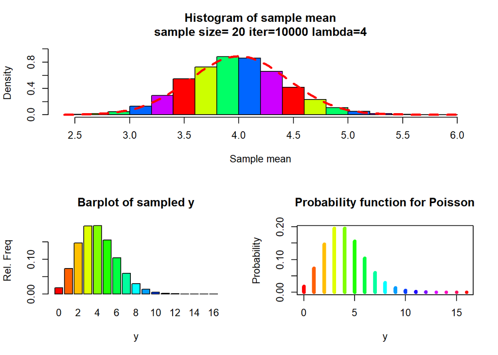

```r
mycltp(n = 20,iter = 10000,lambda = 4)
```

## Iterations lambda=10

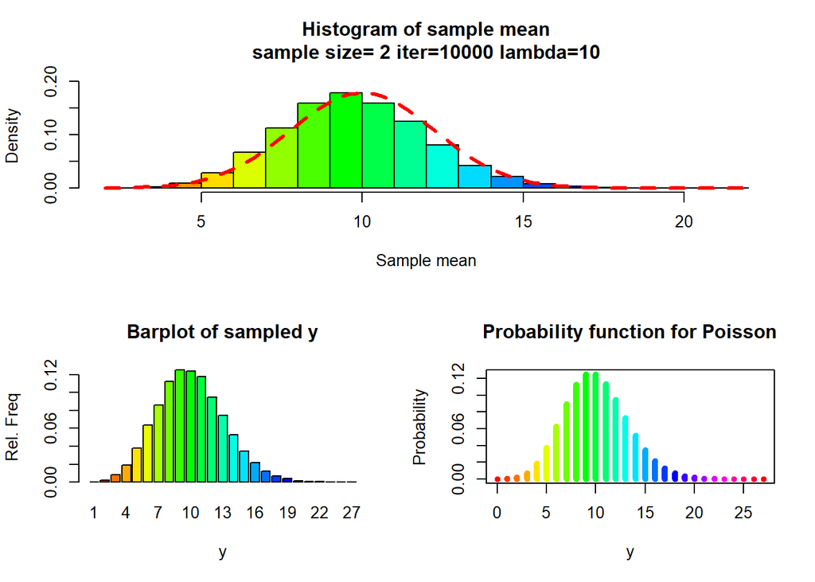

```r
mycltp(n = 2,iter = 10000,lambda = 10)
```

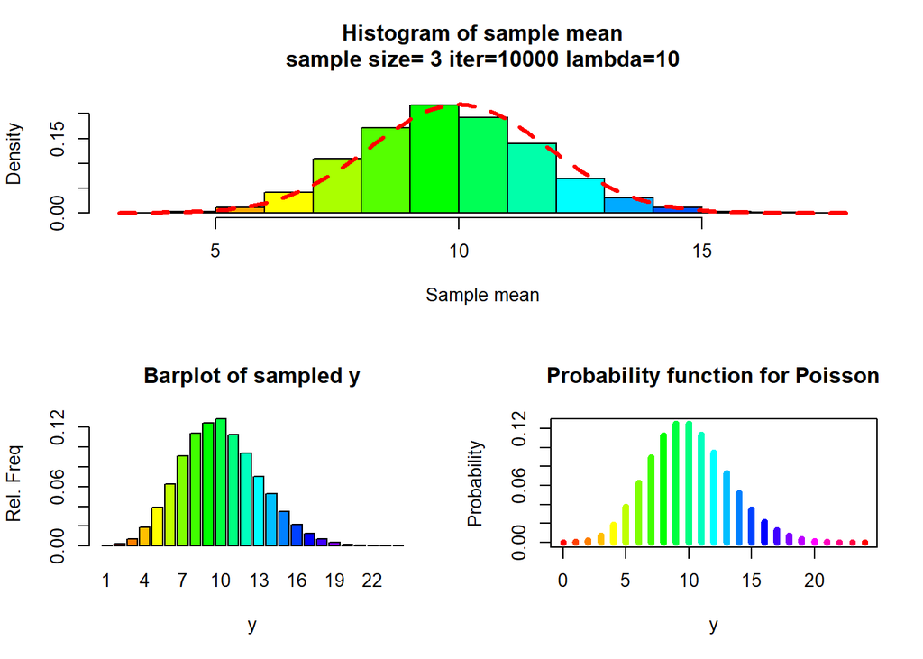

```r
mycltp(n = 3,iter = 10000,lambda = 10)
```

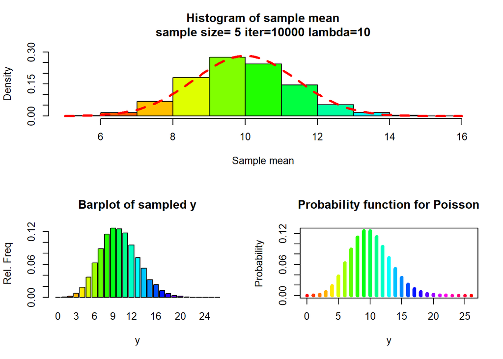

```r
mycltp(n = 5,iter = 10000,lambda = 10)
```